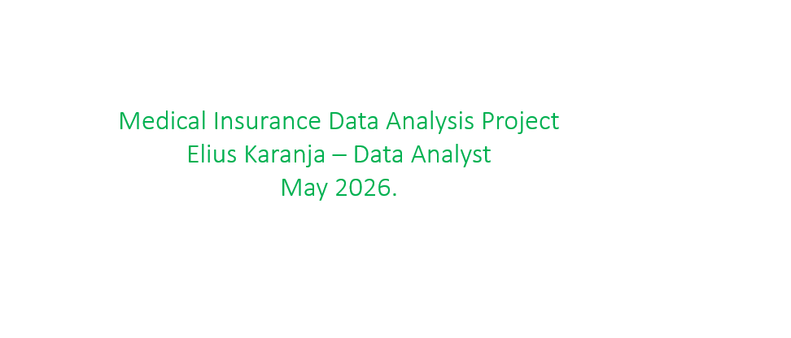

- This project demonstrates how data science is used in healthcare to analyze medical insurance data and understand the factors that influence healthcare costs. The analysis focuses on identifying relationships between demographic characteristics, lifestyle habits, and insurance charges to generate meaningful insights for healthcare decision-making and predictive modeling.

# Project Objectives

The project seeks to:

- Clean and preprocess healthcare insurance data for analysis.
- Explore patterns and trends in medical insurance charges.
- Investigate how demographic factors such as age and gender influence healthcare expenses.
- Examine the impact of lifestyle factors such as smoking habits and Body Mass Index (BMI) on insurance costs.
- Analyze family-related variables such as the number of dependents covered by insurance.
- Compare insurance charges across different geographic regions.

# Importing libraries and loading datasets.

```python
import pandas as pd
import numpy as np
import matplotlib.pyplot as plt
import seaborn as sns
import warnings
warnings.filterwarnings("ignore")
```

```python
kenzo = pd.read_csv("insurance_data.csv")
kenzo
```

|  | age | sex | bmi | children | smoker | region | charges |
| --- | --- | --- | --- | --- | --- | --- | --- |
| 0 | 19 | female | 27.900 | 0 | yes | southwest | 16884.92400 |
| 1 | 18 | male | 33.770 | 1 | no | southeast | 1725.55230 |
| 2 | 28 | male | 33.000 | 3 | no | southeast | 4449.46200 |
| 3 | 33 | male | 22.705 | 0 | no | northwest | 21984.47061 |
| 4 | 32 | male | 28.880 | 0 | no | northwest | 3866.85520 |
| ... | ... | ... | ... | ... | ... | ... | ... |
| 1333 | 50 | male | 30.970 | 3 | no | northwest | 10600.54830 |
| 1334 | 18 | female | 31.920 | 0 | no | northeast | 2205.98080 |
| 1335 | 18 | female | 36.850 | 0 | no | southeast | 1629.83350 |
| 1336 | 21 | female | 25.800 | 0 | no | southwest | 2007.94500 |
| 1337 | 61 | female | 29.070 | 0 | yes | northwest | 29141.36030 |

1338 rows × 7 columns

# Data cleaning.

```python
# cheking for missing values

kenzo.isnull().sum()
```

```
age         0
sex         0
bmi         0
children    0
smoker      0
region      0
charges     0
dtype: int64
```

```python
# cheking for data type.
kenzo.info(type)
```

```
<class 'pandas.core.frame.DataFrame'>
RangeIndex: 1338 entries, 0 to 1337
Data columns (total 7 columns):
 #   Column    Non-Null Count  Dtype
---  ------    --------------  -----
 0   age       1338 non-null   int64
 1   sex       1338 non-null   object
 2   bmi       1338 non-null   float64
 3   children  1338 non-null   int64
 4   smoker    1338 non-null   object
 5   region    1338 non-null   object
 6   charges   1338 non-null   float64
dtypes: float64(2), int64(2), object(3)
memory usage: 73.3+ KB
```

```python
# changing the object variables into categorical variables.

kenzo['sex'] = kenzo['sex'].astype('category')
kenzo['smoker'] = kenzo['smoker'].astype('category')
kenzo["region"] = kenzo["region"].astype("category")
```

```python
kenzo.info()
```

```
<class 'pandas.core.frame.DataFrame'>
RangeIndex: 1338 entries, 0 to 1337
Data columns (total 7 columns):
 #   Column    Non-Null Count  Dtype
---  ------    --------------  -----
 0   age       1338 non-null   int64
 1   sex       1338 non-null   category
 2   bmi       1338 non-null   float64
 3   children  1338 non-null   int64
 4   smoker    1338 non-null   category
 5   region    1338 non-null   category
 6   charges   1338 non-null   float64
dtypes: category(3), float64(2), int64(2)
memory usage: 46.3 KB
```

```python
# cheking for duplicate.
kenzo.duplicated().sum()
```

```
np.int64(1)
```

```python
# droping the dupicates.

kenzo1 = kenzo.drop_duplicates()
kenzo1
```

|  | age | sex | bmi | children | smoker | region | charges |
| --- | --- | --- | --- | --- | --- | --- | --- |
| 0 | 19 | female | 27.900 | 0 | yes | southwest | 16884.92400 |
| 1 | 18 | male | 33.770 | 1 | no | southeast | 1725.55230 |
| 2 | 28 | male | 33.000 | 3 | no | southeast | 4449.46200 |
| 3 | 33 | male | 22.705 | 0 | no | northwest | 21984.47061 |
| 4 | 32 | male | 28.880 | 0 | no | northwest | 3866.85520 |
| ... | ... | ... | ... | ... | ... | ... | ... |
| 1333 | 50 | male | 30.970 | 3 | no | northwest | 10600.54830 |
| 1334 | 18 | female | 31.920 | 0 | no | northeast | 2205.98080 |
| 1335 | 18 | female | 36.850 | 0 | no | southeast | 1629.83350 |
| 1336 | 21 | female | 25.800 | 0 | no | southwest | 2007.94500 |
| 1337 | 61 | female | 29.070 | 0 | yes | northwest | 29141.36030 |

1337 rows × 7 columns

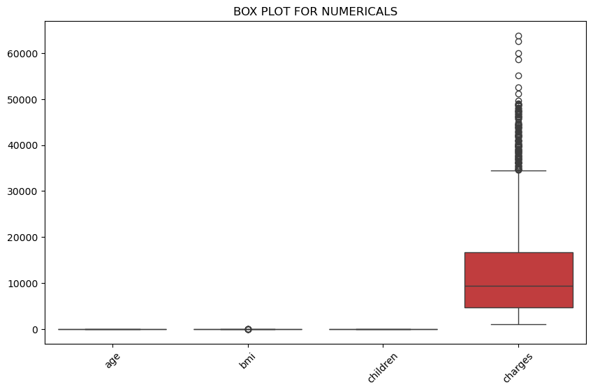

```python
# checking for outliers.
plt.figure(figsize=(10,6))
sns.boxplot(kenzo1)

plt.xticks(rotation=45)
plt.title('BOX PLOT FOR NUMERICALS')
plt.show()
```

```python
# removing outliers in the the bmi.
Q1 = kenzo1["bmi"].quantile(0.25)
Q3 = kenzo1["bmi"].quantile(0.75)
IQR = Q3 - Q1
# DEFINE LOWER AND UPPER BOUNDS
lower_bound = Q1 - 1.5 * IQR
upper_bound = Q3 + 1.5 * IQR
# remove outliers
kenzo2 = kenzo1[(kenzo1["bmi"]>= lower_bound) & (kenzo1["bmi"]<= upper_bound)]
```

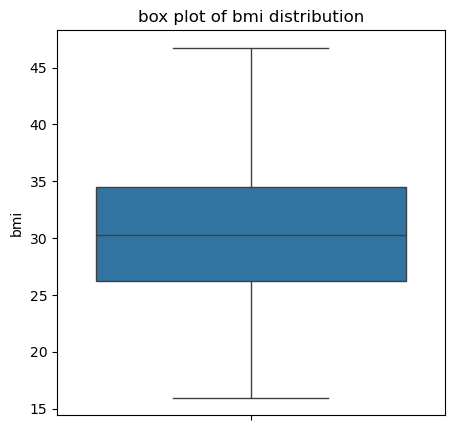

```python
plt.figure(figsize=(5,5))
sns.boxplot(data=kenzo2,y="bmi")
plt.title("box plot of bmi distribution")
plt.ylabel("bmi")
plt.show()
```

```python
Q1 = kenzo2["charges"].quantile(0.25)
Q3 = kenzo2["charges"].quantile(0.75)
IQR = Q3 - Q1
# DEFINE LOWER AND UPPER BOUNDS
lower_bound = Q1 - 1.5 * IQR
upper_bound = Q3 + 1.5 * IQR
# remove outliers
kenzo3 = kenzo2[(kenzo2["charges"]>= lower_bound) & (kenzo2["charges"]<= upper_bound)]
```

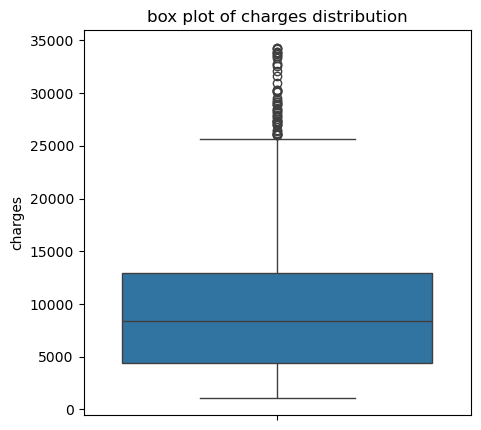

```python
plt.figure(figsize=(5,5))
sns.boxplot(data=kenzo3,y="charges")
plt.title("box plot of charges distribution")
plt.ylabel("charges")
plt.show()
```

```python
Q1 = kenzo3["charges"].quantile(0.25)
Q3 = kenzo3["charges"].quantile(0.75)
IQR = Q3 - Q1
# DEFINE LOWER AND UPPER BOUNDS
lower_bound = Q1 - 1.5 * IQR
upper_bound = Q3 + 1.5 * IQR
# remove outliers
kenzo4 = kenzo3[(kenzo3["charges"]>= lower_bound) & (kenzo3["charges"]<= upper_bound)]
```

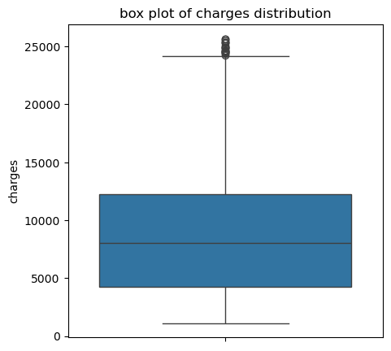

```python
plt.figure(figsize=(5,5))
sns.boxplot(data=kenzo4,y="charges")
plt.title("box plot of charges distribution")
plt.ylabel("charges")
plt.show()
```

```python
Q1 = kenzo4["charges"].quantile(0.25)
Q3 = kenzo4["charges"].quantile(0.75)
IQR = Q3 - Q1
# DEFINE LOWER AND UPPER BOUNDS
lower_bound = Q1 - 1.5 * IQR
upper_bound = Q3 + 1.5 * IQR
# remove outliers
kenzo5 = kenzo4[(kenzo4["charges"]>= lower_bound) & (kenzo4["charges"]<= upper_bound)]
```

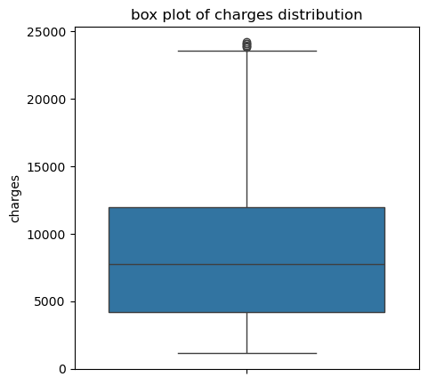

```python
plt.figure(figsize=(5,5))
sns.boxplot(data=kenzo5,y="charges")
plt.title("box plot of charges distribution")
plt.ylabel("charges")
plt.show()
```

```python
Q1 = kenzo5["charges"].quantile(0.25)
Q3 = kenzo5["charges"].quantile(0.75)

IQR = Q3 - Q1
# DEFINE LOWER AND UPPER BOUNDS
lower_bound = Q1 - 1.5 * IQR
upper_bound = Q3 + 1.5 * IQR
# remove outliers
kenzo6 = kenzo5[(kenzo5["charges"]>= lower_bound) & (kenzo5["charges"]<= upper_bound)]
```

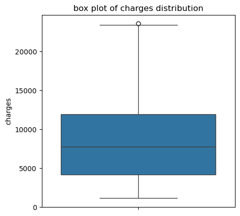

```python
plt.figure(figsize=(5,5))
sns.boxplot(data=kenzo6,y="charges")
plt.title("box plot of charges distribution")
plt.ylabel("charges")
plt.show()
```

```python
Q1 = kenzo6["charges"].quantile(0.25)
Q3 = kenzo6["charges"].quantile(0.75)

IQR = Q3 - Q1
# DEFINE LOWER AND UPPER BOUNDS
lower_bound = Q1 - 1.5 * IQR
upper_bound = Q3 + 1.5 * IQR
# remove outliers
kenzo7 = kenzo6[(kenzo6["charges"]>= lower_bound) & (kenzo6["charges"]<= upper_bound)]
```

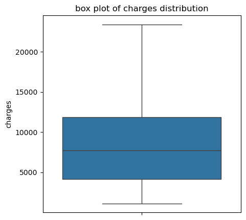

```python
plt.figure(figsize=(5,5))
sns.boxplot(data=kenzo7,y="charges")
plt.title("box plot of charges distribution")
plt.ylabel("charges")
plt.show()
```

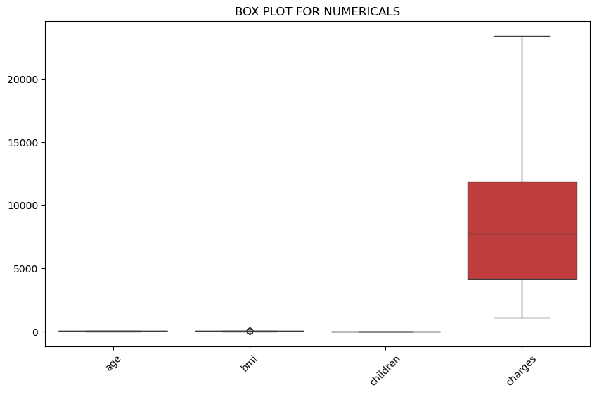

```python
plt.figure(figsize=(10,6))
sns.boxplot(kenzo7)

plt.xticks(rotation=45)
plt.title('BOX PLOT FOR NUMERICALS')
plt.show()
```

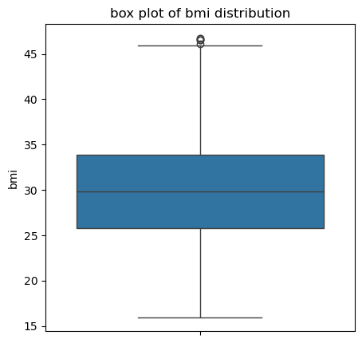

```python
plt.figure(figsize=(5,5))
sns.boxplot(data=kenzo7,y="bmi")
plt.title("box plot of bmi distribution")
plt.ylabel("bmi")
plt.show()
```

```python
Q1 = kenzo7["bmi"].quantile(0.25)
Q3 = kenzo7["bmi"].quantile(0.75)

IQR = Q3 - Q1
# DEFINE LOWER AND UPPER BOUNDS
lower_bound = Q1 - 1.5 * IQR
upper_bound = Q3 + 1.5 * IQR
# remove outliers
kenzo8 = kenzo7[(kenzo7["bmi"]>= lower_bound) & (kenzo7["bmi"]<= upper_bound)]
```

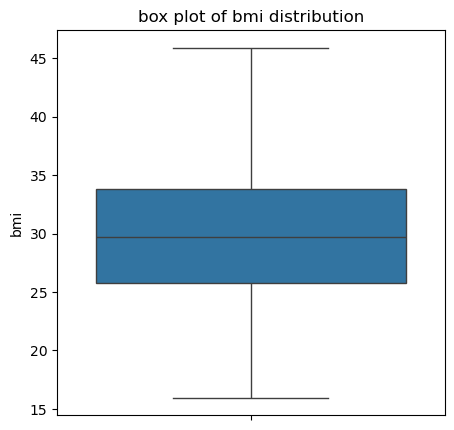

```python
plt.figure(figsize=(5,5))
sns.boxplot(data=kenzo8,y="bmi")
plt.title("box plot of bmi distribution")
plt.ylabel("bmi")
plt.show()
```

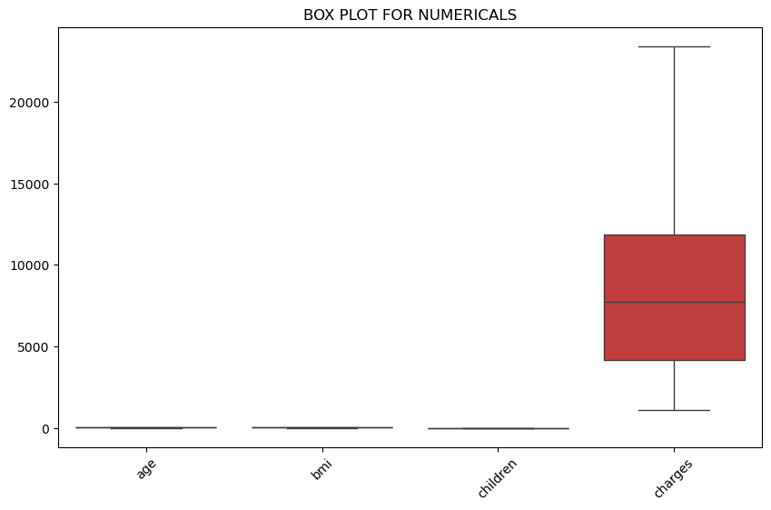

```python
plt.figure(figsize=(10,6))
sns.boxplot(kenzo8)

plt.xticks(rotation=45)
plt.title('BOX PLOT FOR NUMERICALS')
plt.show()
```

# Data visualization

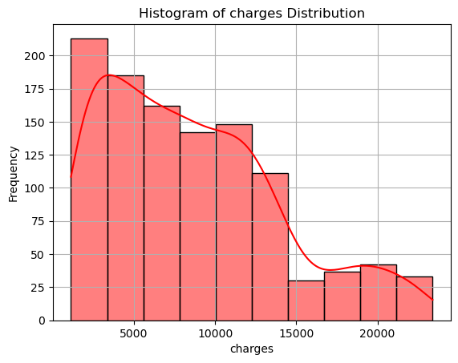

```python
# Histogram for charges.


sns.histplot(data=kenzo8, x="charges", bins=10, kde=True, color="red")

# Add descriptive labels and title to the plot
plt.xlabel("charges")
plt.ylabel("Frequency")
plt.title("Histogram of charges Distribution")

# Add grid lines for better readability of values
plt.grid(True)

# Display the plot
plt.show()
```

# Key insight:

Such a pattern is common in healthcare expenditure data because most people only require routine or moderate medical care, whereas a minority face expensive treatments due to chronic illnesses, severe medical conditions, or risky lifestyle behaviors. From a statistical and modeling perspective, this strong skewness can affect prediction accuracy if the raw data is used directly. Therefore, techniques such as log transformation or robust regression methods may be necessary to reduce the influence of extreme values and produce more reliable insurance cost predictions.

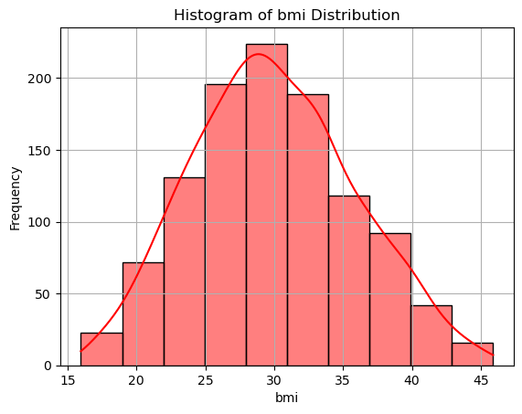

```python
# Histogram for charges.


sns.histplot(data=kenzo8, x="bmi", bins=10, kde=True, color="red")

# Add descriptive labels and title to the plot
plt.xlabel("bmi")
plt.ylabel("Frequency")
plt.title("Histogram of bmi Distribution")

# Add grid lines for better readability of values
plt.grid(True)

# Display the plot
plt.show()
```

### CONCLUSION.

- The dataset indicates that the average BMI of the population is approximately 30. In addition, the distribution of BMI values appears to follow a fairly normal bell-shaped pattern, meaning most individuals are clustered around the average range. There is no strong skewness in either direction, suggesting that BMI values are relatively balanced across the population.

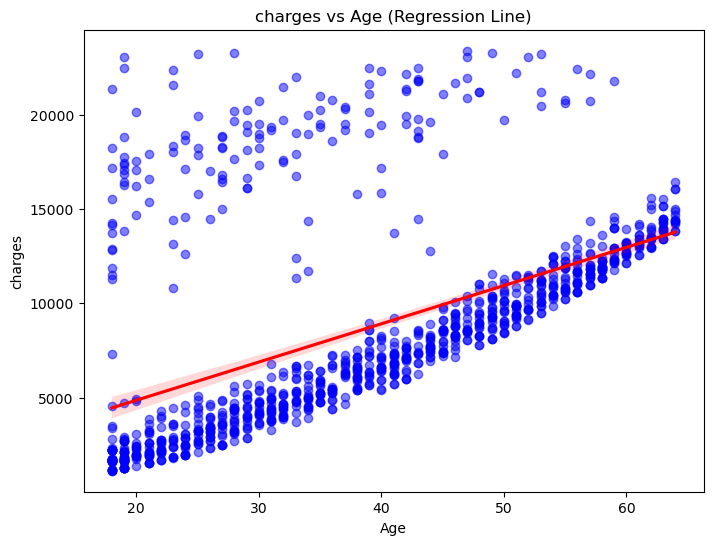

```python
# scatter plot showing pattern of charges vs age.
plt.figure(figsize=(8, 6))
sns.regplot(x='age', y='charges', data=kenzo8, scatter_kws={'alpha':0.5}, line_kws={"color":"red"},color='blue')
plt.title("charges vs Age (Regression Line)")
plt.xlabel("Age")
plt.ylabel("charges")
plt.show()
```

#### CONCLUSION.

- Overall, the data shows a clear positive relationship between age and insurance charges. The upward direction of the red regression line suggests that medical costs tend to increase as individuals grow older. In general, older policyholders are more likely to incur higher healthcare expenses compared to younger individuals.

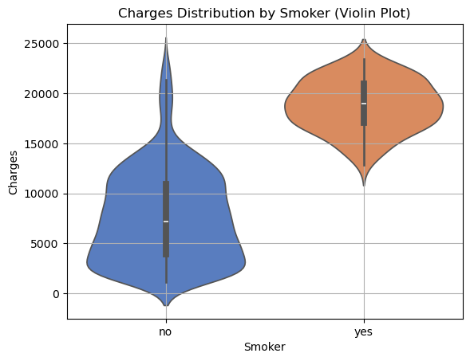

```python
# violin distribution of charegs and gender.

sns.violinplot(x='smoker', y='charges', data=kenzo8, palette='muted')

# Add descriptive title to the plot
plt.title("Charges Distribution by Smoker (Violin Plot)")

# Set x-axis label
plt.xlabel("Smoker")

# Set y-axis label
plt.ylabel("Charges")

# Add grid lines for better readability
plt.grid(True)

# Display the completed plot
plt.show()
```

### CONCLUSION.

- There is a very clear and strong relationship between smoking status and charges. Smokers consistently face much higher costs than non-smokers.

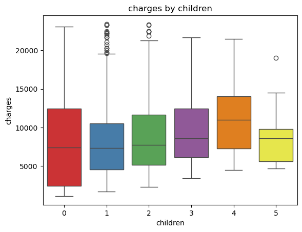

```python
# box plot for children vs charges

sns.boxplot(data=kenzo8, x='children', y='charges', palette='Set1')
plt.title("charges by children")
plt.xlabel("children")
plt.ylabel("charges")
plt.show()
```

## CONCLUSION

- Although households with more children (up to four) tend to show a small increase in median insurance charges, the number of children does not appear to be a major or consistently linear factor affecting healthcare costs. Charges vary widely within each category, indicating that other factors may play a stronger role in determining expenses. In addition, there are several notable outliers, especially among individuals with one or two children, where some policyholders experience exceptionally high medical costs compared to others in the same group.

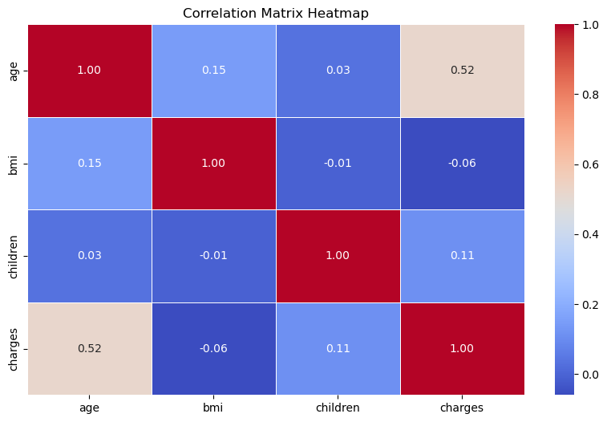

```python
# Heatmap for numerical variambles.

plt.figure(figsize=(10, 6))
corr_matrix = kenzo8.select_dtypes(include=[np.number]).corr()
sns.heatmap(corr_matrix, annot=True, cmap='coolwarm', fmt=".2f", linewidths=0.5)
plt.title("Correlation Matrix Heatmap")
plt.show()
```

## CONCLUSION:

- Among the numerical variables in the dataset, age is the only variable that shows a noticeable linear relationship with insurance charges. This means that as age increases, the final medical charges also tend to rise. In contrast, BMI and the number of children do not display strong linear correlations with the charges in this correlation matrix. Their relationships with insurance costs appear to be weaker or influenced by other interacting factors rather than following a clear direct pattern.

## ONE-SAMPLE T-TEST:

- H0: Sample mean is not significantly different from population mean
- H1: Sample mean is significantlly different from population mean

```python
from scipy import stats

t_statistic, p_value = stats.ttest_1samp(kenzo8["age"], 30)

# Output results
print("t-statistic:", t_statistic)
print("p-value:", p_value)

# Interpret result
alpha = 0.05
if p_value < alpha:
    print("Reject the null hypothesis: sample mean is significantly different from the population mean.")
else:
    print("Fail to reject the null hypothesis: no significant difference between sample and population mean.")
```

```
t-statistic: 20.239660486181105
p-value: 1.0681041016243571e-77
Reject the null hypothesis: sample mean is significantly different from the population mean.
```

### Conclusion.

- since the p-value is < 0.05 we reject H0 and conclude that their is significant difference the sample mean and population mean .

# TWO-SAMPLE TEST.

- H0: The group means are not significantlly different
- H1: The group means are significantlly different

```python
import pingouin as pg

group_A = kenzo8[kenzo8['smoker'] == 'yes']['charges']
group_B = kenzo8[kenzo8['smoker'] == 'no']['charges']

# Perform independent two-sample t-test (Welch's t-test)
two_sample_test = pg.ttest(group_A, group_B, paired=False)
two_sample_test
```

|  | T | dof | alternative | p_val | CI95 | cohen_d | power | BF10 |
| --- | --- | --- | --- | --- | --- | --- | --- | --- |
| T_test | 37.439907 | 156.438843 | two-sided | 5.524400e-80 | [10563.97, 11740.71] | 2.497086 | 1.0 | 1.151e+194 |

### CONCLUSION:

- since the p-value is < 0.05 we reject H0 and conclude that the group means are significantlly different.